# Positron

Initial thoughts on Shiny App/R Package Development

Development Tools

Shiny

Author

Martin Frigaard

Published

October 14, 2024

[figure not shown]

I’ve been trying out Posit’s new Positron IDE for a few weeks, so I put together a post covering my initial impressions of developing Shiny apps and R packages.

## Why switch?

I use RStudio daily for R development and have no complaints about the IDE’s capabilities. However, I’ve recently started using VS Code for Python and JavaScript. When I heard about Positron, I wondered if it would offer enough overlapping features to allow me to use a single IDE for all three languages.

Positron was covered [at posit::conf(2024)](https://youtu.be/8uRcB34Hhsw?si=kVUQOjxNfaZjavLe), and the [Getting Started](https://positron.posit.co/start.html#is-positron-for-me) article on the new website lists reasons you might (or might not) want to switch IDEs. I’ve summarized them below:

### Switch

- You use VS Code or JupyterLab for data science but want more features.
- You want more customization in RStudio.
- You program in languages other than R/Python.

### Don’t switch

- You need reliable and fully functioning software (Positron is still a work-in-progress, so some features may not be stable or polished).
- You need all RStudio’s features (i.e., inline output for Quarto and R Markdown, Sweave, Add-In support, profiling, etc.). Not all these features are implemented in Positron.

**TipDownload and Install Positron**

Positron now has [a website](https://positron.posit.co) with much of the information below (without the screenshots).

Positron can be downloaded from it’s [GitHub repository](https://github.com/posit-dev/positron). I’m running it on my MacBook (2019, 2.6 GHz 6-Core Intel Core i7, macOS Sonoma Version 14.5), so this involved downloading the .dmg file from the [releases page](https://github.com/posit-dev/positron/releases) and installing it like I would any new application.[^1]

## IDE Layout

**NoteNOTE**

Throughout this post, I’ll make the assumption the reader hasn’t spent much time in VS Code (if you have, Positron will be easier to navigate and use).

At first glance, Positron looks like VS Code, but with the four panes we’re used to seeing in RStudio. The default layout includes a Welcome pane with options for opening files and folders above the Panel, which displays the current version of R running:

[figure not shown]

Welcome page

[figure not shown]

Console

The Panel is similar to the **Console** in RStudio but also includes tabs for Terminal, Problems, Output, etc.

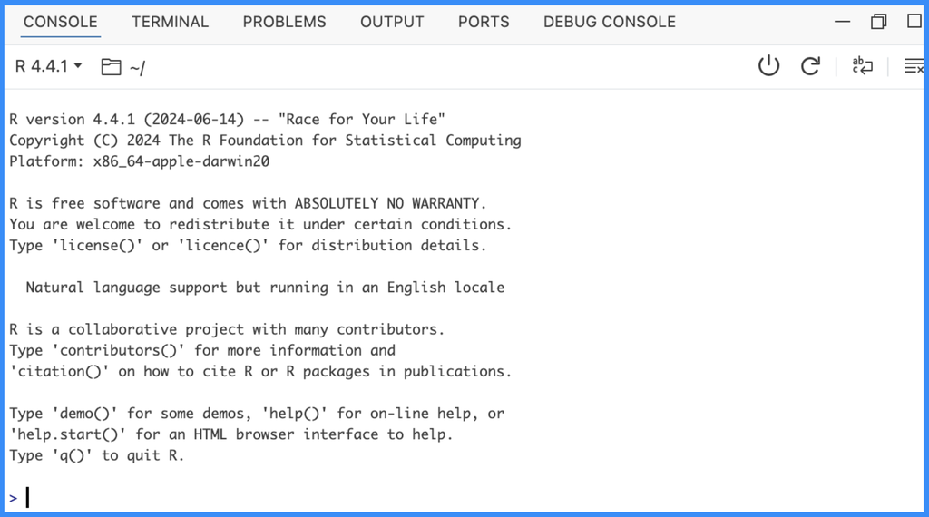

Positron’s panel (click to enlarge)

[figure not shown]

RStudio’s console (click to enlarge)

The Session and Variables[^2] panes are open and initially empty, but we can see this where our Plots will be displayed.

[figure not shown]

Session and Variables (click to enlarge)

### Layout options

To customize Positron’s panes, we can use the layout presets icon (in the upper-right corner of the IDE).

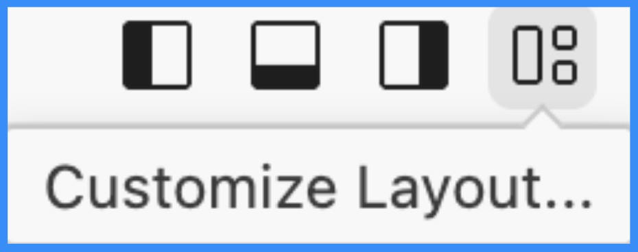

Layout presets icon

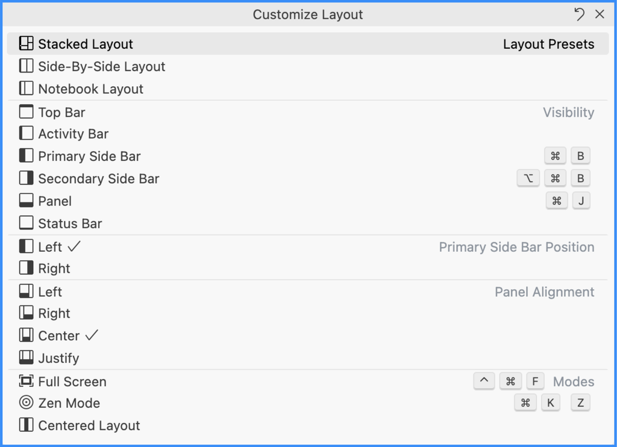

Layout outptions (click to enlarge)

Or we can position each pane manually via **View** > **Appearance** > **Panel Position** …

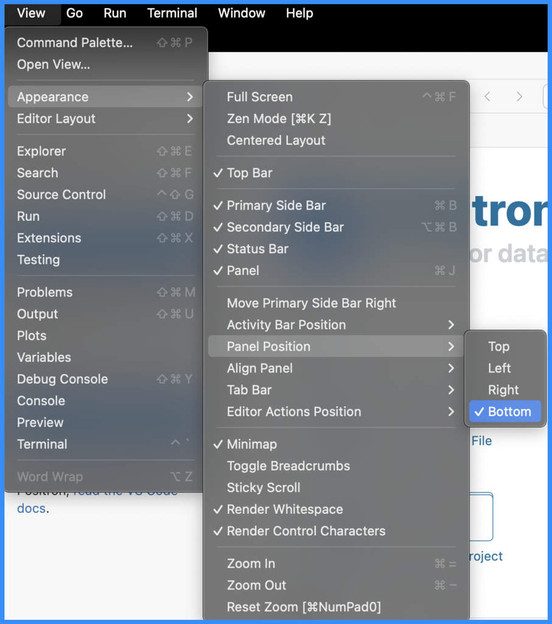

Positron’s view options (click to enlarge)

We’ll continue using the default ‘*Stacked Layout*’ configuration in this post, but I recommend exploring the other options to find a customization that fits your needs.

### R & Python versions

I had R (R 4.4.1) and Python (3.11.5) previously installed, and Positron quickly located both R and Python versions (and displays them in multiple places in the IDE):

[figure not shown]

R versions (click to enlarge)

For more information on detecting Python and R versions, see the [Interpreter Selection](https://positron.posit.co/interpreters.html) section of the documentation.

### R Dependencies

Positron’s documentation recommends installing the following packages:[^3]

```r
pak::pak(c("usethis", "cli", "crayon",
           "rlang", "roxygen2", "pkgload"))
```

### Files, Folders and Projects

I use the folder icon in the upper right corner of the IDE to locate and open project folders. Still, Positron has multiple options for opening project folders from the welcome page and with the explorer sidebar menu item:

[figure not shown]

Open folder (click to enlarge)

I’ll be using my [`sap`](https://github.com/mjfrigaard/sap) repository because it contains the following:

1. Version control
2. An R project (i.e., with an `.Rproj` file)
3. A Shiny app
4. An R package[^4]

### Activity bar

One of Positron’s major distinguishing factors is its activity bar. This sidebar lets us open and edit files, perform searches, access source control (like Git), and find/install extensions.

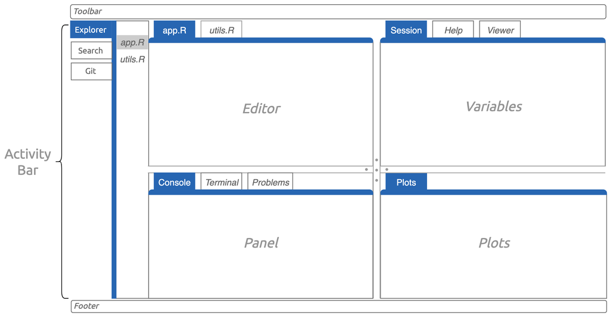

Positron Layout (click to enlarge)

I’ll briefly cover a few of Positron’s sidebar menu items in the sections below.

#### Explorer

[figure not shown]

As noted above, the Explorer menu item can open project files and folders.

This closely resembles the **Files** pane in RStudio.

[figure not shown]

Shiny app files (click to enlarge)

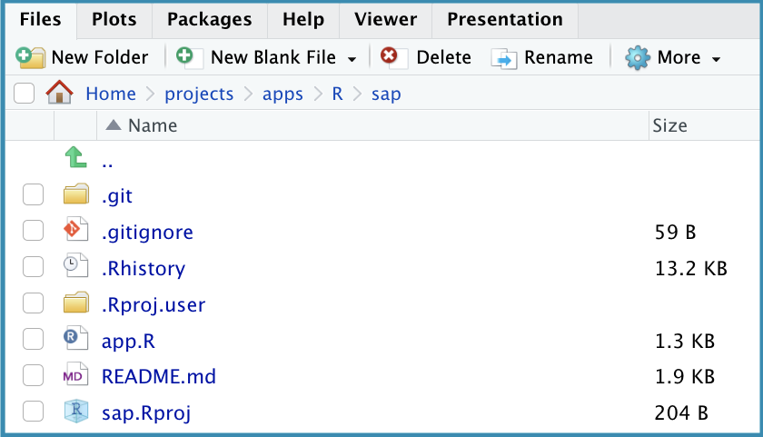

RStudio Files Pane (click to enlarge)

Clicking on files in the Explorer will open them in the Editor. After opening files, the cursor location will also display additional information on hover (i.e., version control information):

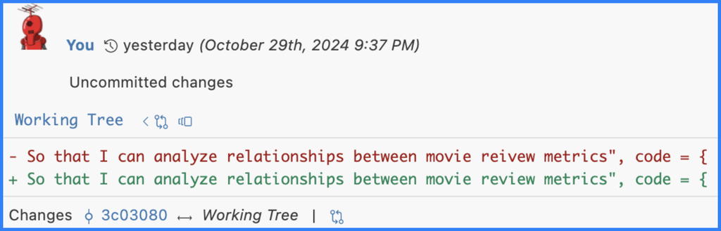

Hover information in Editor (click to enlarge)

#### Search

[figure not shown]

The Search menu item allows us to find and replace across all files.

Similar to the **Find in Files** (`Ctrl` + `Shift` + `F`) window in RStudio.

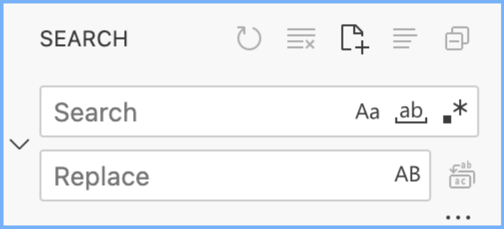

Search and replace (click to enlarge)

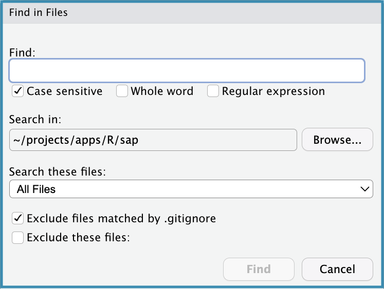

RStudio ‘Find in Files’ (click to enlarge)

#### Source Control

[figure not shown]

The Source Control menu can open local Git folders and clone repositories.

When in a Git repo, it displays Git commits, branches, remotes, stashes, tags, work trees, and contributors (similar to the **Git pane** in RStudio).

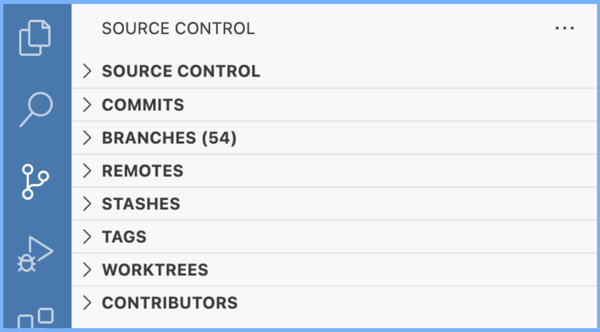

Source control menu (click to enlarge)

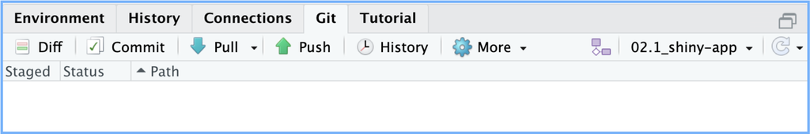

RStudio Git Pane (click to enlarge)

In RStudio, I still use the Terminal for ~90% of my interactions with Git, but Positron also comes with a Source Control menu.[^5]

[figure not shown]

Checking out Git branch with Source Control (click to enlarge)

#### Extensions

[figure not shown]

We can install Positron extensions from the **Extensions** menu item.

Positron’s extensions are somewhat similar to RStudio Addins but with a few key differences:

1. Positron extensions enhance the IDE’s capabilities by interacting with the VS Code API. They can range from language support (e.g., R, Python) to tools and features for general coding tasks (debugging, version control, syntax highlighting, code snippets, etc.)
2. [RStudio Addins](https://rstudio.github.io/rstudio-extensions/rstudio_addins.html) are custom tools and features to extend IDE’s functionality, focusing on R-specific tasks (package development, customizing visualizations, R markdown document generation, etc.)

[figure not shown]

Positron Extensions via Positron +1e (click to enlarge)

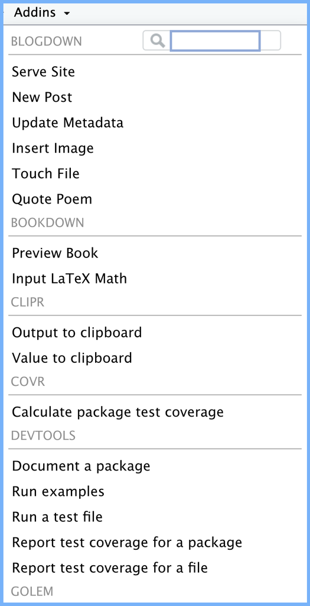

RStudio Addins (click to enlarge)

At a minimum, be sure to install the [Posit Publisher extension](https://open-vsx.org/extension/posit/publisher). I’ve also installed [Positron +1e](https://open-vsx.org/extension/grrrck/positron-plus-1-e), a collection of extensions curated by Garrick Aden-Buie[^6] for ‘*git-backed data science and dev work shared primarily on GitHub*’.

**TipPositron Extensions**

Extensions can be installed from [VS Code Marketplace](https://marketplace.visualstudio.com/) or the [Open VXS Registry](https://open-vsx.org/). VS Code Marketplace is maintained by Microsoft, ensuring high-quality and secure extensions, whereas the Open VXS Registry is an open-source alternative for those looking to avoid vendor lock-in.[^7] Most extensions on Open VXS Registry are identical to those found on the VS Code marketplace, but with a focus on open-source principles.

For more Positron extensions, I recommend checking out [this post](https://www.andrewheiss.com/blog/2024/07/08/fun-with-positron/#my-extensions) from Andrew Heiss[^8] and [this LinkedIn post](https://www.linkedin.com/posts/veerlevanleemput_positron-r-rstats-activity-7221481394013642752-60Pg?utm_source=share&utm_medium=member_desktop) from Veerle van Leemput.[^9]

## Shiny Apps

I’ve checked out a branch of `sap` that’s in the early stages of development, so it’s a Shiny app (and not an R package yet).[^10] The image below highlights some of the IDE’s features after opening the app.R file:

[figure not shown]

Open `app.R` file (click to enlarge)

Positron displays the current folder (or project) in a familiar location, and the active Git branch and Quarto version are conveniently placed in the footer.

As we can see from the image above, Positron displays much of the same information as the RStudio IDE but with a VS Code*ish* layout. The most notable change I had to adapt to was the new location of the project files in the file Explorer.

### Running Applications

Positron detects that I’m developing a Shiny application and places a Run Shiny App icon at the top of the `app.R` file. Clicking the Run Shiny App button launches our application in the Viewer pane.

[figure not shown]

Terminal runs the Shiny app (click to enlarge)

[figure not shown]

Unlike RStudio, Positron runs Shiny applications from the Terminal with a dedicated Shiny process when the Run Shiny App button is clicked.

In the Terminal, a message tells us that `autoreload` has been turned on (which means we can make live updates to our application):

[figure not shown]

Live updates to Shiny app

**TipRun Shiny App Terminal Commands**

I’ve broken down the Shiny terminal commands below:

The first commands specifies the `Rscript` interpreter, the scripting front-end for R. `Rscript` allows the execution of R scripts directly from the command line.

```bash
# Rscript interpreter
$/usr/local/bin/Rscript
```

The next command is the path to an R script that comes with your Positron installation for running Shiny applications.

```bash
# runShinyApp.R Positron Shiny extension
$/Users/username/.positron/extensions/posit.shiny-1.0.0-universal/rscripts/runShinyApp.R
```

You can view the contents of `runShinyApp.R` by passing the path into another Terminal window preceded by `cat`.

The final Terminal command is the path to the `moviesApp` Shiny application’s main `app.R` script (with two additional arguments):

```bash
# moviesApp app.R file
/Users/username/projects/apps/R/moviesApp/app.R 51146 --devmode
```

- `51146` specifies the port on which the Shiny application will run.
- `--devmode` enables development mode for the Shiny application.[^11]